# Experiment 4

Darrell Penta

April 15, 2015

## I. EXP OVERVIEW

### a. What you did

- You saw a whole punch of letter string, one after another
- *Primes* and *Targets*, both of which had **word** and **non-word** versions
- You just answered yes or no
- There was also a delay in the timing between the presentation of the prime and the target
- For word-word target-prime pairings, half of the words share an association

| IV | Level |
| --- | --- |
| Prime | Word, Non-word |
| Targets | Word, Non-word |
| ISI (inter-stimulus interval) | 50ms, 100ms, 200, 350, 500 |
| Association | association (half the words), not-associated |

Accuracy | Were you right whether the yes no key press matched target type

### b. Experimental questions

- *Question here is about timing of information flow in the system*
  - This is an examination of activition system view of long-term memory (LTM) in which activation is a quantity tha can spread around
  - Example: Seeing **EMERALD** should activate your knowledge of emerald and things related to it, like **DIAMOND**
- The system tracks these realtionships and uses them during day-to-day operations
- *How is knowledge organized in long-term memory?*

## II. BACKGROUND

### Activitation system (a. Theory 1)

- *Nodes* which represent something/perice of knowledge that can collect activation
- Activation happens quickly, and nodes can activate/deactive quickly
- *Connections/Links* between nodes, with activation spreading through the links.
  - The system change over time (you can learn new things)
- *Nodes* have 2 activation levels:
  - Resting level (non-zero level, but low) is the baseline
  - current level is dynamic, changes based on things like are you thinking about that word or reading that word, etc
  - Current level and Resting level can be = and presumably are most of the time
- *Connections* have weights/strenghts:
  - How much information spread at a given moment
  - Exmample: Due to connection weights, more likely that *EMERALD* spreads activation to *DIAMOND*, but less to *GREEN*
  - weights set by prior experience
  - can change over time by learning based on experience
- Assocation is not the only kind of relationship

Associative words speed up/prime activation * Can be one way

Ratcliff & McKoon Can mess around with episodic memory People learn: “The doctor kissed the lawyer” They gave people words in tests where the target is something like lawyer, and the preceding word was either from the sentence they learned or not

PARAMETRIC EXPERIMENT We’re looking at a specific parameter of the system (namely, how quickly activation can spread/timing of activation spread)

Unassociated pairing are the baseline. Associated should be faster than baseline Looking at whether activation has spread to the target or not Look at: short ISIs tell us how quickly activation spreads long ISIs tell us now long activation remains

## II. METHOD

### Participants:

16 NU Undergrads

### Apparatus:

MicroExperimental lab sortware running DOS

## Results

### 1. Which Analyses

#### Results

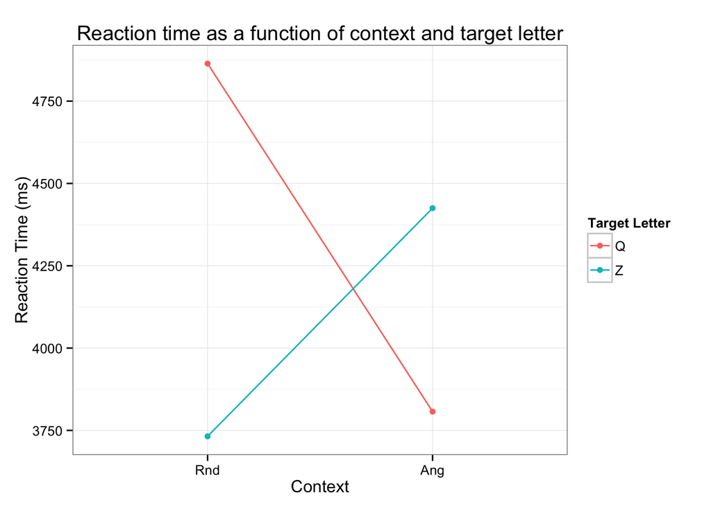

## Results (15)

- dropped Analyses factorial analysis:
- collapsing;
- describe pattern;
- refer to fig;

Feature Theory (Talked about in Intro):

- Knows and cares about *amount* of overlap
- computes this overlap by comparing number of features shared (e.g., Q vs. D): (, ), ~ vs. ), |
- more shared features means slower reaction times
- Q<sub>ROUND</sub> > Q<sub>ANGULAR</sub>
- Z<sub>ROUND</sub> <= Z<sub>ANGULAR</sub>

# Discussion

- Template theory doesn’t have a way of talking about anything other than overall overlap
- It doesn’t say anything about combinations (It shouldn’t know that a Q overlapped with a D has some overlap with a Q overlapped with a V)
- Predicts no interaction between target and context
- Specific pattern of results matches the feature theory predictions
- WE can define a specific set of features for the relevant letters, and we can define a function that computes amount of overlap
  - we have a set of features counted up (see table)

#### Calculating % overlap:

Eq: (% overlap = # features matching / # of features in context

| Target x context | Match/Total | Percentage |
| --- | --- | --- |
| Q<sub>ROUND</sub> | 2/5 | 40 |
| Q<sub>ANGULAR</sub> | 1/8 | 12.5 |
| Z<sub>ROUND</sub> | 0/5 | 0 |
| Z<sub>ANGULAR</sub> | 1/8 | 12.5 |

Because we don’t see a perfect match in the computations and the results, there’s more to the story -potential problem: we’re not considering how many times each of the features appear, we might want to adjust the function to weight features

We found an interaction, which fits with the feature theory but does not fit with the template theory -What might you do to the template theory to explain the pattern?

## Discussion (15)

- compare results w/predictions (recap predictions if needed)
- no effect of target or context, compatible w/either theory, but interaction inconsistent w/Template and consistent w/Feature;
- explain meaning of slope (time to scan a row) [and mention goodness of fit to regression line for earlier vs later rows (optional; should be here or in Results; nothing to do for Spr2015)];
- discuss augmentation of Template;
- discuss Structural Feature Theory (if not covered in Intro);
- cover detailed feature theory and quantitative predictions here, relating to ANOVA results, etc. (some flexibility about how much they say about quantitative feature predictions, but they should present a feature-breakdown and work out % of overlap, relating to results, at a minimum);
- usual general issues & extensions

## FIGS AND TABLES (15)

graph for RT by target and context

graph for RT by row, including regression line

check axis labels, axis tick spacing, graph titles, etc.

### READINGS:

- Levy, C.M., & Ransdell, S. E. (1988). *Laboratory in cognition and perception (2nd ed.).* Iowa City: CONDUIT, Univ. of Iowa.
- Neisser, U. (1967) *Cognitive Psychology*. Englewood Cliffs, NJ: Prentice-Hall. [Neisser (1967)](http://infinitychallenge.com/articles/Neisser_1967.pdf)
- Reed, S.K. (1998) *Cognition: Theory and appliciations*. Pacific Grove, CA: Brooks/Cole. [Reed (1988)](http://infinitychallenge.com/articles/Reed_1988.pdf)
- Schneider, W. (1988) Micro Experimental Laboratory: An integrated system for IBM PC compatibles: *Behavior Research Methods, Instruments, & Computers, 20*, 206-217.